# Texto Blog

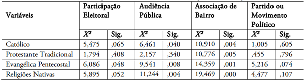

Figura 2: Participação Política Convencional e Organizações Religiosas.

Para a análise logística, os autores consideraram participar das religiões Católica, Evangélica e Nativas como variáveis independentes para formar os modelos de 1 a 3, compostos, respectivamente por audiência pública, associação de bairro e partido ou movimento político. Estas variáveis foram utilizadas a partir da frequência a cultos e missas, que faziam parte das variáveis independentes utilizadas por denominação religiosa. Em seguida, utilizaram também a regressão logística a partir das variáveis dependentes participação eleitoral, audiência pública e associação de bairro. Para estas, utilizaram-se os dados de participação convencional, ao invés da frequência a atividades religiosas.

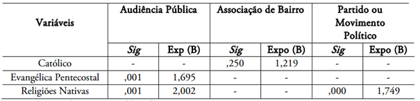

Figura 3: Regressão Logística para Participação Convencional por Frequência a Cultos e Missas.

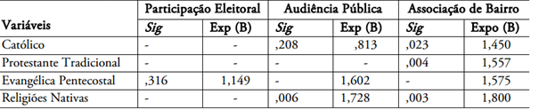

Figura 4: Regressão Logística para Participação Convencional por Organizações Religiosas.

Além destas análises, levaram em consideração também a participação política não convencional e a frequência a cultos e missas, bem como a participação política não convencional e meramente o comparecimento a organizações religiosas, como segue:

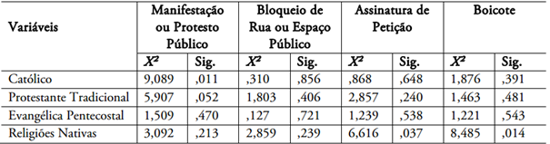

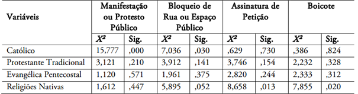

Para a survey “A Cara da Democracia”, a qual também é de grande relevância para as nossas análises de dados, para a sua versão do ano de 2019 selecionamos as seguintes perguntas abaixo. Nelas, percebemos a qualidade dos dados levados em consideração pelos organizadores da survey, sendo que as suas perguntas são extremamente relevantes para o nosso trabalho proposto. Com relação à democracia, levaremos em conta as perguntas de grau de satisfação com a democracia brasileira e partidos políticos de simpatia. Sobre engajar-se politicamente e habilidades cívicas, a survey proporciona a análise das variáveis de o quanto se interessa por política, se participa de atividades políticas além do voto, se participa ou já participou de uma série de organizações não governamentais e se participa de igreja ou organização religiosa (considerar envolvimento em atividades desenvolvidas na igreja, tais como grupo de jovens, pastorais, associações vinculadas etc., não considerando aqueles que declaram frequentar apenas cultos ou missas – esta era uma observação no formulário para o entrevistador). Alguns exemplos de modelos a serem analisados levam em consideração as seguintes variáveis dependentes: • Variáveis dependentes: o O quanto se interessa por política; o Participou de alguma atividade política além de votar; o Assinar petição; o Participar de boicotes; o Participar de manifestação e protestos; o Participar de greves; o Bloquear trânsito; o Ocupar prédios, fábricas, terrenos e escolas; o Participar de mobilizações organizadas apenas via internet; o Participar de grupos de política no WhatsApp. • Variáveis independentes: Religião ou frequência com que vai à missa e atividades religiosas, gênero, idade, renda, situação profissional e estado civil. Para os dados de “A Cara da Democracia” de 2020 infelizmente não temos informações acerca da participação política e exercício das habilidades cívicas, como tínhamos para o ano anterior. Neste ano, temos apenas algumas informações relativas a preferências políticas e como elas podem estar relacionadas à adesão religiosa. A partir dos dados acima listados, também realizaremos uma regressão do tipo logit, semelhante à anterior, dos dados do LAPOP. Ainda uma terceira e última base de dados complementa a nossa análise, que é a da Pew Research Center, em um relatório chamado de “Religion in Latin America, Widespread Change in a Historically Catholic Region”. Ela evidencia, para o ano de 2014, em específico, uma série de mudanças demográficas e socioculturais em uma região historicamente católica, como sugere o título, a América Latina. A pesquisa é constituída de 181 perguntas, divididas para respondentes católicos, protestantes ou “não-afiliados”. A pesquisa contém dados para uma amostra significativa de países da América Latina. Entretanto, focaremos apenas no caso brasileiro, como é a proposta do presente trabalho. É possível fazer estatísticas com gênero, escolaridade, renda, idade para cada uma das variáveis dependentes de grupo religioso consideradas. Entretanto, o foco será, baseados no artigo “Religious Engagement, Civic Skills, and Political Pariticipation in Latin America” (AUDETTE; CORNEJO; BROCKWAY, 2020), realizar a atualização da regressão logística para os dados do Brasil. Originalmente, o artigo se baseou nos dados agregados de toda a América Latina, o que é um erro em nossa concepção, já que deveríamos privilegiar os países em suas singularidades e sutilezas. Assim, utilizaremos os dados, especificamente de Brasil, para realização da regressão logística entre as variáveis “Any Church Involvement”, “Level of Church Involvement”, “Any Prayer Group Involvement” e “Level of Prayer Group Involvement” para as variáveis dependentes grupos religiosos, bem como as variáveis de controle: gênero, estado civil, idade, etnia, educação, renda, se urbano ou rural, e se imigrante. Depois, para estas mesmas variáveis dependentes, utilizaremos as variáveis “Community Work”, “Protest” e “Contact Official”. Dessa maneira, podemos sintetizar a relação entre as variáveis dependentes e independentes desta base de dados da seguinte maneira abaixo, separando-a por uma análise das características sociodemográficas da participação religiosa e, em seguida, da participação política (AUDETTE; CORNEJO; BROCKWAY, 2020): • Variáveis dependentes: o Se envolvimento em atividades religiosas (variável categórica binária); o Nível de envolvimento em atividades religiosas (variável categórica); o Se envolvimento em algum grupo de oração (variável categórica binária); o Nível de envolvimento em grupos de oração (variável categórica). • Variáveis independentes: o Religião, gênero, estado civil, idade, etnia, níveis educacionais, renda, se população urbana ou rural e se imigrante.

Para uma análise da participação política levaremos em consideração as seguintes variáveis dependentes e independentes (AUDETTE; CORNEJO; BROCKWAY, 2020): • Variáveis dependentes: o Trabalho comunitário; o Protesto; o Contatar um representar da política parlamentar. • Variáveis independentes: o Religião, nível de envolvimento em atividade religiosa, participação em grupos de oração, frequência de idas à igreja, gênero, estado civil, idade, etnia, educação, se urbano ou rural e se imigrante.

## Análise

Para cada base de dados, podemos pensar em alguns testes estatísticos que corroborem à nossa análise.

A começar pelas bases de dados do LAPOP para o ano de 2017:

```r
multinom(Participação ~ Religião, data = X2016_17_Stata)
```

```
## Call:
## multinom(formula = Participação ~ Religião, data = X2016_17_Stata)
##
## Coefficients:
##                          (Intercept) ReligiãoAteu ReligiãoCatólico
## Uma ou duas vezes ao ano   -1.945070    0.8463723        0.1029031
## Uma ou duas vezes ao mês   -2.639006    0.8472017       -0.3733346
## Uma vez por semana         -2.639043  -11.6768990       -0.1725179
##                          ReligiãoEspírita ReligiãoEvangélica ReligiãoNenhuma
## Uma ou duas vezes ao ano       -0.7631245         0.35117013       0.1326861
## Uma ou duas vezes ao mês        1.5403842         0.08954537       0.3566066
## Uma vez por semana            -15.0562134        -0.60344441      -0.1541550
##                          ReligiãoOutra ReligiãoProtestante
## Uma ou duas vezes ao ano   -0.76314974          0.04796039
## Uma ou duas vezes ao mês   -0.06910903         -1.45540394
## Uma vez por semana          0.62414356          0.33648245
##                          ReligiãoTestemunha de Jeová
## Uma ou duas vezes ao ano                 -14.3654561
## Uma ou duas vezes ao mês                   0.4417742
## Uma vez por semana                       -12.8142906
##
## Residual Deviance: 1245.021
## AIC: 1299.021
```

```r
modelo1 <- multinom(Participação ~ Religião, data = X2016_17_Stata)
summary(multinom(Participação ~ Religião, data = X2016_17_Stata))
```

```
## Call:
## multinom(formula = Participação ~ Religião, data = X2016_17_Stata)
##
## Coefficients:
##                          (Intercept) ReligiãoAteu ReligiãoCatólico
## Uma ou duas vezes ao ano   -1.945070    0.8463723        0.1029031
## Uma ou duas vezes ao mês   -2.639006    0.8472017       -0.3733346
## Uma vez por semana         -2.639043  -11.6768990       -0.1725179
##                          ReligiãoEspírita ReligiãoEvangélica ReligiãoNenhuma
## Uma ou duas vezes ao ano       -0.7631245         0.35117013       0.1326861
## Uma ou duas vezes ao mês        1.5403842         0.08954537       0.3566066
## Uma vez por semana            -15.0562134        -0.60344441      -0.1541550
##                          ReligiãoOutra ReligiãoProtestante
## Uma ou duas vezes ao ano   -0.76314974          0.04796039
## Uma ou duas vezes ao mês   -0.06910903         -1.45540394
## Uma vez por semana          0.62414356          0.33648245
##                          ReligiãoTestemunha de Jeová
## Uma ou duas vezes ao ano                 -14.3654561
## Uma ou duas vezes ao mês                   0.4417742
## Uma vez por semana                       -12.8142906
##
## Std. Errors:
##                          (Intercept) ReligiãoAteu ReligiãoCatólico
## Uma ou duas vezes ao ano   0.7556876     1.112545        0.7687893
## Uma ou duas vezes ao mês   1.0351236     1.496050        1.0629078
## Uma vez por semana         1.0351403   524.309212        1.0581593
##                          ReligiãoEspírita ReligiãoEvangélica ReligiãoNenhuma
## Uma ou duas vezes ao ano     1.2797908577          0.7857078       0.8464468
## Uma ou duas vezes ao mês     1.1567829864          1.0859538       1.1366143
## Uma vez por semana           0.0001902984          1.1310652       1.1938396
##                          ReligiãoOutra ReligiãoProtestante
## Uma ou duas vezes ao ano      1.279800           0.8359668
## Uma ou duas vezes ao mês      1.462258           1.4450657
## Uma vez por semana            1.279912           1.1201987
##                          ReligiãoTestemunha de Jeová
## Uma ou duas vezes ao ano               0.00003505693
## Uma ou duas vezes ao mês               1.47736188021
## Uma vez por semana                     0.00189390992
##
## Residual Deviance: 1245.021
## AIC: 1299.021
```

```r
multinom(Participação ~ Religião, data = NovaBase201617)
```

```
## Call:
## multinom(formula = Participação ~ Religião, data = NovaBase201617)
##
## Coefficients:
##                          (Intercept) ReligiãoAteu ReligiãoCatólico
## Uma ou duas vezes ao ano   -1.945070    0.8463723        0.1029031
## Uma ou duas vezes ao mês   -2.639006    0.8472017       -0.3733346
## Uma vez por semana         -2.639043  -11.6768990       -0.1725179
##                          ReligiãoEspírita ReligiãoEvangélica ReligiãoNenhuma
## Uma ou duas vezes ao ano       -0.7631245         0.35117013       0.1326861
## Uma ou duas vezes ao mês        1.5403842         0.08954537       0.3566066
## Uma vez por semana            -15.0562134        -0.60344441      -0.1541550
##                          ReligiãoOutra ReligiãoProtestante
## Uma ou duas vezes ao ano   -0.76314974          0.04796039
## Uma ou duas vezes ao mês   -0.06910903         -1.45540394
## Uma vez por semana          0.62414356          0.33648245
##                          ReligiãoTestemunha de Jeová
## Uma ou duas vezes ao ano                 -14.3654561
## Uma ou duas vezes ao mês                   0.4417742
## Uma vez por semana                       -12.8142906
##
## Residual Deviance: 1245.021
## AIC: 1299.021
```

```r
summary(multinom(Participação ~ Religião, data = NovaBase201617))
```

```
## Call:
## multinom(formula = Participação ~ Religião, data = NovaBase201617)
##
## Coefficients:
##                          (Intercept) ReligiãoAteu ReligiãoCatólico
## Uma ou duas vezes ao ano   -1.945070    0.8463723        0.1029031
## Uma ou duas vezes ao mês   -2.639006    0.8472017       -0.3733346
## Uma vez por semana         -2.639043  -11.6768990       -0.1725179
##                          ReligiãoEspírita ReligiãoEvangélica ReligiãoNenhuma
## Uma ou duas vezes ao ano       -0.7631245         0.35117013       0.1326861
## Uma ou duas vezes ao mês        1.5403842         0.08954537       0.3566066
## Uma vez por semana            -15.0562134        -0.60344441      -0.1541550
##                          ReligiãoOutra ReligiãoProtestante
## Uma ou duas vezes ao ano   -0.76314974          0.04796039
## Uma ou duas vezes ao mês   -0.06910903         -1.45540394
## Uma vez por semana          0.62414356          0.33648245
##                          ReligiãoTestemunha de Jeová
## Uma ou duas vezes ao ano                 -14.3654561
## Uma ou duas vezes ao mês                   0.4417742
## Uma vez por semana                       -12.8142906
##
## Std. Errors:
##                          (Intercept) ReligiãoAteu ReligiãoCatólico
## Uma ou duas vezes ao ano   0.7556876     1.112545        0.7687893
## Uma ou duas vezes ao mês   1.0351236     1.496050        1.0629078
## Uma vez por semana         1.0351403   524.309212        1.0581593
##                          ReligiãoEspírita ReligiãoEvangélica ReligiãoNenhuma
## Uma ou duas vezes ao ano     1.2797908577          0.7857078       0.8464468
## Uma ou duas vezes ao mês     1.1567829864          1.0859538       1.1366143
## Uma vez por semana           0.0001902984          1.1310652       1.1938396
##                          ReligiãoOutra ReligiãoProtestante
## Uma ou duas vezes ao ano      1.279800           0.8359668
## Uma ou duas vezes ao mês      1.462258           1.4450657
## Uma vez por semana            1.279912           1.1201987
##                          ReligiãoTestemunha de Jeová
## Uma ou duas vezes ao ano               0.00003505693
## Uma ou duas vezes ao mês               1.47736188021
## Uma vez por semana                     0.00189390992
##
## Residual Deviance: 1245.021
## AIC: 1299.021
```

```r
lm(Associação ~ Religião, data = X2016_17_Stata)
```

```
##
## Call:
## lm(formula = Associação ~ Religião, data = X2016_17_Stata)
##
## Coefficients:
##                 (Intercept)                 ReligiãoAteu
##                     1.38889                     -0.16667
##            ReligiãoCatólico             ReligiãoEspírita
##                     0.02490                      0.37302
##          ReligiãoEvangélica              ReligiãoNenhuma
##                     0.03123                     -0.09658
##               ReligiãoOutra          ReligiãoProtestante
##                     0.19006                     -0.02047
## ReligiãoTestemunha de Jeová
##                    -0.18889
```

```r
glm(Audiência ~ Religião, data = X2016_17_Stata, family = "binomial")
```

```
##
## Call:  glm(formula = Audiência ~ Religião, family = "binomial", data = X2016_17_Stata)
##
## Coefficients:
##                 (Intercept)                 ReligiãoAteu
##                    -0.22314                     -1.02962
##            ReligiãoCatólico             ReligiãoEspírita
##                    -1.39148                     -0.06454
##          ReligiãoEvangélica              ReligiãoNenhuma
##                    -1.35120                     -1.16315
##               ReligiãoOutra          ReligiãoProtestante
##                    -0.80648                     -0.87547
## ReligiãoTestemunha de Jeová
##                    -1.97408
##
## Degrees of Freedom: 850 Total (i.e. Null);  842 Residual
## Null Deviance:       831.3
## Residual Deviance: 813.9     AIC: 831.9
```

```r
modelo3 <- glm(Audiência ~ Religião, data = X2016_17_Stata, family = "binomial")

summary(glm(X2016_17_Stata$Audiência ~ X2016_17_Stata$Religião, family="binomial"))
```

```
##
## Call:
## glm(formula = X2016_17_Stata$Audiência ~ X2016_17_Stata$Religião,
##     family = "binomial")
##
## Deviance Residuals:
##     Min       1Q   Median       3Q      Max
## -1.0842  -0.6136  -0.6024  -0.6024   2.1460
##
## Coefficients:
##                                            Estimate Std. Error z value Pr(>|z|)
## (Intercept)                                -0.22314    0.47434  -0.470  0.63805
## X2016_17_Stata$ReligiãoAteu                -1.02962    0.93159  -1.105  0.26906
## X2016_17_Stata$ReligiãoCatólico            -1.39148    0.49048  -2.837  0.00455
## X2016_17_Stata$ReligiãoEspírita            -0.06454    0.64765  -0.100  0.92062
## X2016_17_Stata$ReligiãoEvangélica          -1.35120    0.51636  -2.617  0.00888
## X2016_17_Stata$ReligiãoNenhuma             -1.16315    0.56670  -2.052  0.04012
## X2016_17_Stata$ReligiãoOutra               -0.80648    0.70458  -1.145  0.25236
## X2016_17_Stata$ReligiãoProtestante         -0.87547    0.54330  -1.611  0.10709
## X2016_17_Stata$ReligiãoTestemunha de Jeová -1.97408    1.15582  -1.708  0.08765
##
## (Intercept)
## X2016_17_Stata$ReligiãoAteu
## X2016_17_Stata$ReligiãoCatólico            **
## X2016_17_Stata$ReligiãoEspírita
## X2016_17_Stata$ReligiãoEvangélica          **
## X2016_17_Stata$ReligiãoNenhuma             *
## X2016_17_Stata$ReligiãoOutra
## X2016_17_Stata$ReligiãoProtestante
## X2016_17_Stata$ReligiãoTestemunha de Jeová .
## ---
## Signif. codes:  0 '***' 0.001 '**' 0.01 '*' 0.05 '.' 0.1 ' ' 1
##
## (Dispersion parameter for binomial family taken to be 1)
##
##     Null deviance: 831.34  on 850  degrees of freedom
## Residual deviance: 813.87  on 842  degrees of freedom
## AIC: 831.87
##
## Number of Fisher Scoring iterations: 4
```

```r
Logit(Audiência ~ Religião, data = NovaBase201617)
```

```
##
## Response Variable:   Audiência
## Predictor Variable 1:  Religião
##
## Number of cases (rows) of data:  851
## Number of cases retained for analysis:  851
##
##
##    BASIC ANALYSIS
##
## Estimated Model for the Logit of Reference Group Membership
##
##                              Estimate    Std Err  z-value  p-value   Lower 95%   Upper 95%
##                 (Intercept)   -0.2231     0.4743   -0.470    0.638     -1.1528      0.7065
##                ReligiãoAteu   -1.0296     0.9316   -1.105    0.269     -2.8555      0.7963
##            ReligiãoCatólico   -1.3915     0.4905   -2.837    0.005     -2.3528     -0.4302
##            ReligiãoEspírita   -0.0645     0.6476   -0.100    0.921     -1.3339      1.2048
##          ReligiãoEvangélica   -1.3512     0.5164   -2.617    0.009     -2.3632     -0.3392
##             ReligiãoNenhuma   -1.1632     0.5667   -2.052    0.040     -2.2739     -0.0524
##               ReligiãoOutra   -0.8065     0.7046   -1.145    0.252     -2.1874      0.5745
##         ReligiãoProtestante   -0.8755     0.5433   -1.611    0.107     -1.9403      0.1894
## ReligiãoTestemunha de Jeová   -1.9741     1.1558   -1.708    0.088     -4.2395      0.2913
##
##
## Odds Ratios and Confidence Intervals
##
##                              Odds Ratio   Lower 95%   Upper 95%
##                 (Intercept)      0.8000      0.3157      2.0270
##                ReligiãoAteu      0.3571      0.0575      2.2172
##            ReligiãoCatólico      0.2487      0.0951      0.6504
##            ReligiãoEspírita      0.9375      0.2634      3.3362
##          ReligiãoEvangélica      0.2589      0.0941      0.7124
##             ReligiãoNenhuma      0.3125      0.1029      0.9489
##               ReligiãoOutra      0.4464      0.1122      1.7762
##         ReligiãoProtestante      0.4167      0.1437      1.2085
## ReligiãoTestemunha de Jeová      0.1389      0.0144      1.3382
##
##
## Model Fit
##
```

[output cut: 82 more lines]

```
## ---------------------------------------------------
##                  Total  %Tot        0      1  %Correct
## ---------------------------------------------------
##             1      163  19.2      163      0     0.0
## Audiência   0      688  80.8      688      0     100.0
## ---------------------------------------------------
##           Total    851                           80.8
##
## Accuracy: 80.85
## Sensitivity: 0.00
## Precision: NaN
##
##
##
## >>> No scatterplot matrix reported because not all variables are numeric.
```

```r
summary(Logit(Audiência ~ Religião, data = NovaBase201617))
```

```
##
## Response Variable:   Audiência
## Predictor Variable 1:  Religião
##
## Number of cases (rows) of data:  851
## Number of cases retained for analysis:  851
##
##
##    BASIC ANALYSIS
##
## Estimated Model for the Logit of Reference Group Membership
##
##                              Estimate    Std Err  z-value  p-value   Lower 95%   Upper 95%
##                 (Intercept)   -0.2231     0.4743   -0.470    0.638     -1.1528      0.7065
##                ReligiãoAteu   -1.0296     0.9316   -1.105    0.269     -2.8555      0.7963
##            ReligiãoCatólico   -1.3915     0.4905   -2.837    0.005     -2.3528     -0.4302
##            ReligiãoEspírita   -0.0645     0.6476   -0.100    0.921     -1.3339      1.2048
##          ReligiãoEvangélica   -1.3512     0.5164   -2.617    0.009     -2.3632     -0.3392
##             ReligiãoNenhuma   -1.1632     0.5667   -2.052    0.040     -2.2739     -0.0524
##               ReligiãoOutra   -0.8065     0.7046   -1.145    0.252     -2.1874      0.5745
##         ReligiãoProtestante   -0.8755     0.5433   -1.611    0.107     -1.9403      0.1894
## ReligiãoTestemunha de Jeová   -1.9741     1.1558   -1.708    0.088     -4.2395      0.2913
##
##
## Odds Ratios and Confidence Intervals
##
##                              Odds Ratio   Lower 95%   Upper 95%
##                 (Intercept)      0.8000      0.3157      2.0270
##                ReligiãoAteu      0.3571      0.0575      2.2172
##            ReligiãoCatólico      0.2487      0.0951      0.6504
##            ReligiãoEspírita      0.9375      0.2634      3.3362
##          ReligiãoEvangélica      0.2589      0.0941      0.7124
##             ReligiãoNenhuma      0.3125      0.1029      0.9489
##               ReligiãoOutra      0.4464      0.1122      1.7762
##         ReligiãoProtestante      0.4167      0.1437      1.2085
## ReligiãoTestemunha de Jeová      0.1389      0.0144      1.3382
##
##
## Model Fit
##
```

[output cut: 82 more lines]

```
## ---------------------------------------------------
##                  Total  %Tot        0      1  %Correct
## ---------------------------------------------------
##             1      163  19.2      163      0     0.0
## Audiência   0      688  80.8      688      0     100.0
## ---------------------------------------------------
##           Total    851                           80.8
##
## Accuracy: 80.85
## Sensitivity: 0.00
## Precision: NaN
##
##
##
## >>> No scatterplot matrix reported because not all variables are numeric.
```

[output not shown]

```r
Logit(Audiência ~ Religião, data = NovaBase201617)
```

```
##
## Response Variable:   Audiência
## Predictor Variable 1:  Religião
##
## Number of cases (rows) of data:  851
## Number of cases retained for analysis:  851
##
##
##    BASIC ANALYSIS
##
## Estimated Model for the Logit of Reference Group Membership
##
##                              Estimate    Std Err  z-value  p-value   Lower 95%   Upper 95%
##                 (Intercept)   -0.2231     0.4743   -0.470    0.638     -1.1528      0.7065
##                ReligiãoAteu   -1.0296     0.9316   -1.105    0.269     -2.8555      0.7963
##            ReligiãoCatólico   -1.3915     0.4905   -2.837    0.005     -2.3528     -0.4302
##            ReligiãoEspírita   -0.0645     0.6476   -0.100    0.921     -1.3339      1.2048
##          ReligiãoEvangélica   -1.3512     0.5164   -2.617    0.009     -2.3632     -0.3392
##             ReligiãoNenhuma   -1.1632     0.5667   -2.052    0.040     -2.2739     -0.0524
##               ReligiãoOutra   -0.8065     0.7046   -1.145    0.252     -2.1874      0.5745
##         ReligiãoProtestante   -0.8755     0.5433   -1.611    0.107     -1.9403      0.1894
## ReligiãoTestemunha de Jeová   -1.9741     1.1558   -1.708    0.088     -4.2395      0.2913
##
##
## Odds Ratios and Confidence Intervals
##
##                              Odds Ratio   Lower 95%   Upper 95%
##                 (Intercept)      0.8000      0.3157      2.0270
##                ReligiãoAteu      0.3571      0.0575      2.2172
##            ReligiãoCatólico      0.2487      0.0951      0.6504
##            ReligiãoEspírita      0.9375      0.2634      3.3362
##          ReligiãoEvangélica      0.2589      0.0941      0.7124
##             ReligiãoNenhuma      0.3125      0.1029      0.9489
##               ReligiãoOutra      0.4464      0.1122      1.7762
##         ReligiãoProtestante      0.4167      0.1437      1.2085
## ReligiãoTestemunha de Jeová      0.1389      0.0144      1.3382
##
##
## Model Fit
##
```

[output cut: 82 more lines]

```
## ---------------------------------------------------
##                  Total  %Tot        0      1  %Correct
## ---------------------------------------------------
##             1      163  19.2      163      0     0.0
## Audiência   0      688  80.8      688      0     100.0
## ---------------------------------------------------
##           Total    851                           80.8
##
## Accuracy: 80.85
## Sensitivity: 0.00
## Precision: NaN
##
##
##
## >>> No scatterplot matrix reported because not all variables are numeric.
```

## A Cara da Democracia

```r
# Interesse por Política
modelo9 <-
  multinom(interesse ~ relig + freqigreja + sexo + idade + fx.renda + sit + estcivil,
           data = Banco_de_Dados_A_Cara_da_Democracia_2019)
summary(modelo9)
```

```
## Call:
## multinom(formula = interesse ~ relig + freqigreja + sexo + idade +
##     fx.renda + sit + estcivil, data = Banco_de_Dados_A_Cara_da_Democracia_2019)
##
## Coefficients:
##    (Intercept)        relig   freqigreja      sexo        idade    fx.renda
## 2   -0.4293616 -0.001154861  0.025022228 0.4073794 0.0026539230  0.05045374
## 3    1.2555444 -0.006169842 -0.004173992 0.4643696 0.0009089647 -0.11168611
## 4    0.9895070 -0.004552601  0.016707632 0.6077391 0.0078874945 -0.26062650
## 88  -1.4209189  0.007779045  0.019004897 0.1166041 0.0074067878 -0.24131354
## 99  -6.8003348 -0.154028408  0.057413813 1.0410248 0.0299249202  0.25099763
##             sit     estcivil
## 2   0.007616614  0.093261869
## 3   0.012610605  0.064964157
## 4   0.023535029  0.036233730
## 88  0.040045190 -0.006582593
## 99 -0.039059283  0.138278917
##
## Std. Errors:
##    (Intercept)       relig freqigreja      sexo       idade   fx.renda
## 2    0.5885465 0.005944217 0.04721712 0.2190148 0.007209312 0.06412274
## 3    0.5376497 0.005535094 0.04778207 0.1981677 0.006498669 0.05836629
## 4    0.5418929 0.005578203 0.04673274 0.2008330 0.006571769 0.06013164
## 88   1.0359620 0.008635445 0.07812189 0.3963308 0.012627161 0.12646737
## 99   2.8481185 0.282470743 0.06867771 0.9652511 0.033882128 0.26818154
##           sit   estcivil
## 2  0.02113069 0.07949355
## 3  0.01904764 0.07243863
## 4  0.01918841 0.07291898
## 88 0.03654825 0.13632461
## 99 0.09560235 0.30438142
##
## Residual Deviance: 5082.36
## AIC: 5162.36
```

```r
# Participar de alguma atividade política além de votar
modelo10 <-
  multinom(atv ~ relig + freqigreja + sexo + idade + fx.renda + sit + estcivil,
           data = Banco_de_Dados_A_Cara_da_Democracia_2019)
summary(modelo10)
```

```
## Call:
## multinom(formula = atv ~ relig + freqigreja + sexo + idade +
##     fx.renda + sit + estcivil, data = Banco_de_Dados_A_Cara_da_Democracia_2019)
##
## Coefficients:
##    (Intercept)         relig  freqigreja       sexo        idade      fx.renda
## 2     2.220030  0.0008469071 -0.02155284 -0.2253991  0.017884222 -0.0003740763
## 88   -1.360186 -0.0476956937  0.01562410 -0.3632548  0.005508817 -0.2739612640
## 99  -63.857913 -3.5007883746  1.14594660  7.0079253 -0.879030062 25.2649146408
##             sit    estcivil
## 2    0.03476648 -0.05946079
## 88   0.06104293 -0.04729053
## 99 -63.07818622  1.04888358
##
## Std. Errors:
##    (Intercept)      relig freqigreja       sexo       idade   fx.renda
## 2    0.4820349 0.00563042 0.02010239  0.1857836 0.006337145 0.05926841
## 88   1.5508342 0.09660815 0.04722819  0.6200399 0.019149634 0.21797987
## 99   0.7612177 3.89972729 1.48205852 10.5268814 0.486239209 4.80948516
##           sit   estcivil
## 2  0.01794001 0.06830297
## 88 0.05571688 0.20766609
## 99 0.76121773 2.37224325
##
## Residual Deviance: 1129.169
## AIC: 1177.169
```

```r
modelo11 <-
  multinom(acao1 ~ relig + freqigreja + sexo + idade + fx.renda + sit + estcivil,
           data = Banco_de_Dados_A_Cara_da_Democracia_2019)
summary(modelo11)
```

```
## Call:
## multinom(formula = acao1 ~ relig + freqigreja + sexo + idade +
##     fx.renda + sit + estcivil, data = Banco_de_Dados_A_Cara_da_Democracia_2019)
##
## Coefficients:
##    (Intercept)         relig   freqigreja        sexo         idade   fx.renda
## 2     1.940011 -0.0038023953  -0.01958906 -0.41923178 -0.0014890623 -0.1980298
## 3     1.080496 -0.0052242031  -0.07334097 -0.08998712  0.0259377509 -0.3290418
## 88   -2.955645  0.0007133825  -0.07761144 -0.55821486  0.0138372015 -0.1910994
## 99 -274.109500 -5.5798654300 -10.26472495 96.88736607  0.0004543778 -0.7594516
##           sit    estcivil
## 2  0.01079572 -0.06673261
## 3  0.02353194 -0.05607081
## 88 0.12574997  0.06270525
## 99 7.22211100 -5.97450915
##
## Std. Errors:
##    (Intercept)       relig freqigreja      sexo       idade   fx.renda
## 2   0.35473711 0.003718250 0.02487648 0.1309714 0.004414807 0.04019143
## 3   0.35573011 0.003927377 0.03225604 0.1282284 0.004240450 0.03965577
## 88  1.22556772 0.012924238 0.12725681 0.4617779 0.013560870 0.14002330
## 99  0.01467325 0.117609884 0.09461051 0.0293465 0.132330235 2.23259200
##           sit   estcivil
## 2  0.01249218 0.04835509
## 3  0.01184619 0.04441209
## 88 0.04343971 0.13020048
## 99 0.22060936 0.10609104
##
## Residual Deviance: 4223.121
## AIC: 4287.121
```

```r
modelo12 <-
  multinom(acao2 ~ relig + freqigreja + sexo + idade + fx.renda + sit + estcivil,
           data = Banco_de_Dados_A_Cara_da_Democracia_2019)
summary(modelo12)
```

```
## Call:
## multinom(formula = acao2 ~ relig + freqigreja + sexo + idade +
##     fx.renda + sit + estcivil, data = Banco_de_Dados_A_Cara_da_Democracia_2019)
##
## Coefficients:
##    (Intercept)        relig   freqigreja       sexo       idade    fx.renda
## 2     2.624619 -0.008922922 -0.004991841  0.1335172 -0.01068032 -0.05210196
## 3     3.435019 -0.010996576 -0.029611354  0.2894002  0.01180993 -0.10140607
## 88    1.860851 -0.540676760 -0.062147322  0.2978387 -0.01354303 -0.12315506
## 99    2.232704 -0.018809100  0.008644915 -0.9857757 -0.04379011 -0.22323255
##             sit    estcivil
## 2  -0.011910509  0.04471451
## 3   0.005825554  0.04121020
## 88  0.058661347  0.12242289
## 99  0.085737491 -0.71241734
##
## Std. Errors:
##    (Intercept)      relig freqigreja      sexo      idade  fx.renda        sit
## 2    1.0085578 0.00821785 0.03410136 0.3923722 0.01317045 0.1184836 0.03767689
## 3    0.9676739 0.00767883 0.03636861 0.3756503 0.01256328 0.1130640 0.03597492
## 88   1.7708572 0.24205952 0.13262635 0.5641181 0.01764752 0.1712528 0.05116232
## 99   3.6026662 0.04685204 0.12811526 1.4204890 0.04810649 0.4169387 0.12230937
##     estcivil
## 2  0.1478440
## 3  0.1408922
## 88 0.1947834
## 99 0.7285066
##
## Residual Deviance: 2176.611
## AIC: 2240.611
```

```r
modelo13 <-
  multinom(v69 ~ relig + freqigreja + sexo + idade + fx.renda + sit + estcivil,
           data = Banco_de_Dados_A_Cara_da_Democracia_2019)
summary(modelo13)
```

```
## Call:
## multinom(formula = v69 ~ relig + freqigreja + sexo + idade +
##     fx.renda + sit + estcivil, data = Banco_de_Dados_A_Cara_da_Democracia_2019)
##
## Coefficients:
##   (Intercept)        relig  freqigreja       sexo         idade    fx.renda
## 2    2.475372 -0.003841606 -0.04006733 -0.1337371 -0.0011445810 -0.19120516
## 3    2.071174 -0.005487088 -0.10875799 -0.0762740  0.0325078746 -0.31906847
## 4   -1.693970 -0.032276926 -0.08421926 -0.3137063 -0.0004350653  0.05030982
## 5   12.791573 -1.497416158  0.16522758 -1.3781181 -0.0240247875 -0.40954381
##           sit     estcivil
## 2 -0.00811523 -0.128073307
## 3  0.01928898 -0.111969436
## 4  0.01459496  0.001797527
## 5  0.13719268 -8.237960299
##
## Std. Errors:
##   (Intercept)       relig freqigreja      sexo       idade   fx.renda
## 2   0.4604211 0.004300671 0.03635373 0.1666451 0.005745495 0.05024490
## 3   0.4450933 0.004320679 0.03975782 0.1604264 0.005421445 0.04829708
## 4   1.3953475 0.043053290 0.13956408 0.4950911 0.016420084 0.13934412
## 5   3.2534237 1.688489410 0.40704876 1.4315253 0.045760883 0.40672674
##          sit   estcivil
## 2 0.01605256 0.06266254
## 3 0.01514892 0.05768458
## 4 0.04699724 0.17849111
## 5 0.12469741 3.31854519
##
## Residual Deviance: 3645.553
## AIC: 3709.553
```

```r
modelo14 <-
  multinom(v70 ~ relig + freqigreja + sexo + idade + fx.renda + sit + estcivil,
           data = Banco_de_Dados_A_Cara_da_Democracia_2019)
summary(modelo14)
```

```
## Call:
## multinom(formula = v70 ~ relig + freqigreja + sexo + idade +
##     fx.renda + sit + estcivil, data = Banco_de_Dados_A_Cara_da_Democracia_2019)
##
## Coefficients:
##   (Intercept)         relig   freqigreja        sexo        idade   fx.renda
## 2    3.280273 -0.0009004514  0.009614353 -0.05021077 -0.029330544 -0.1855307
## 3    3.140925 -0.0029019564 -0.137591430 -0.17567707  0.013255478 -0.2947179
## 4   -1.167928  0.0226372724 -0.151366623  0.23626221  0.000744818 -0.2157555
## 5    6.611469 -1.3213899366  0.056673881  0.53480822 -0.012453300 -0.1321611
##           sit   estcivil
## 2 0.005397965 -0.1077037
## 3 0.037096518 -0.1323455
## 4 0.040341109 -0.1804903
## 5 0.060825787 -5.6723405
##
## Std. Errors:
##   (Intercept)       relig freqigreja      sexo       idade   fx.renda
## 2   0.4831847 0.005195249 0.02986948 0.1790850 0.006174772 0.05358896
## 3   0.4679311 0.005268822 0.03730090 0.1712737 0.005753393 0.05068284
## 4   1.2908756 0.008057691 0.12800013 0.4599734 0.014816785 0.13940476
## 5   2.7211907 1.327261560 0.38260038 1.3230628 0.046445560 0.36428382
##          sit   estcivil
## 2 0.01754332 0.06422402
## 3 0.01646645 0.05799290
## 4 0.04014535 0.15532191
## 5 0.11202096 3.06392145
##
## Residual Deviance: 3510.488
## AIC: 3574.488
```

```r
modelo15 <-
  multinom(acao6 ~ relig + freqigreja + sexo + idade + fx.renda + sit + estcivil,
           data = Banco_de_Dados_A_Cara_da_Democracia_2019)
summary(modelo15)
```

```
## Call:
## multinom(formula = acao6 ~ relig + freqigreja + sexo + idade +
##     fx.renda + sit + estcivil, data = Banco_de_Dados_A_Cara_da_Democracia_2019)
##
## Coefficients:
##    (Intercept)        relig    freqigreja        sexo       idade   fx.renda
## 2    2.8654351 -0.009607388   0.034074392 -0.05109830 -0.01436836 -0.1618721
## 3    4.1172305 -0.010460174  -0.003521084 -0.12837740  0.01249056 -0.2181883
## 88   0.5497484 -0.041729184   0.025290150 -0.01171576 -0.02151742 -0.2561477
## 99 -16.1993449 -5.437836720 -11.126942283  8.81303847 -0.01441453 -0.5761920
##            sit    estcivil
## 2  -0.01645635 -0.04722839
## 3   0.01760750 -0.09592366
## 88  0.10921874 -0.11920654
## 99  2.32370930 -6.48658613
##
## Std. Errors:
##    (Intercept)       relig freqigreja       sexo       idade   fx.renda
## 2   0.88445441 0.007320694 0.07109197 0.32121259 0.010929933 0.09548794
## 3   0.82038975 0.006479651 0.07014312 0.29595433 0.009959501 0.08686243
## 88  1.38969121 0.042238939 0.09111408 0.53631096 0.016339755 0.16268628
## 99  0.01578997 0.042830117 0.01888645 0.03158184 0.141496971 2.35680081
##           sit   estcivil
## 2  0.03104683 0.11539744
## 3  0.02835760 0.10404675
## 88 0.04777535 0.18428469
## 99 0.21936181 0.01814714
##
## Residual Deviance: 2093.929
## AIC: 2157.929
```

```r
modelo16 <-
  multinom(acao7 ~ relig + freqigreja + sexo + idade + fx.renda + sit + estcivil,
           data = Banco_de_Dados_A_Cara_da_Democracia_2019)
summary(modelo16)
```

```
## Call:
## multinom(formula = acao7 ~ relig + freqigreja + sexo + idade +
##     fx.renda + sit + estcivil, data = Banco_de_Dados_A_Cara_da_Democracia_2019)
##
## Coefficients:
##    (Intercept)       relig    freqigreja         sexo        idade    fx.renda
## 2    1.3580550 -0.01357246  -0.003392274  0.001573247 0.0005204443 -0.06113962
## 3    3.6175659 -0.01513980  -0.043984940 -0.148623851 0.0366608608 -0.08597993
## 88  -0.9639329 -0.01258341  -0.005183307 -0.116903118 0.0148091907  0.04447310
## 99  -5.3463705 -6.15380321 -12.162384245  2.484573223 0.0003656283 -0.26748763
##           sit    estcivil
## 2  0.05144772  0.26626832
## 3  0.04361904  0.07635042
## 88 0.07619741  0.21653231
## 99 2.73005640 -7.99169811
##
## Std. Errors:
##    (Intercept)       relig freqigreja       sexo      idade  fx.renda
## 2   1.42776382 0.009470595 0.03183936 0.52306210 0.02033912 0.1668979
## 3   1.36206100 0.008300888 0.04059924 0.49177192 0.01938516 0.1568457
## 88  1.69651371 0.013567305 0.04330977 0.64025790 0.02341384 0.1990070
## 99  0.01542454 0.044644887 0.01653571 0.03121617 0.14756989 2.3933600
##           sit   estcivil
## 2  0.05399307 0.22676687
## 3  0.05143877 0.21683758
## 88 0.06347200 0.25868572
## 99 0.22782321 0.01630521
##
## Residual Deviance: 1364.417
## AIC: 1428.417
```

```r
modelo17 <-
  multinom(v73 ~ relig + freqigreja + sexo + idade + fx.renda + sit + estcivil,
           data = Banco_de_Dados_A_Cara_da_Democracia_2019)
summary(modelo17)
```

```
## Call:
## multinom(formula = v73 ~ relig + freqigreja + sexo + idade +
##     fx.renda + sit + estcivil, data = Banco_de_Dados_A_Cara_da_Democracia_2019)
##
## Coefficients:
##   (Intercept)          relig   freqigreja        sexo       idade   fx.renda
## 2   3.0620766 -0.00008889661  0.006898978 -0.07322591 -0.01604677 -0.2155341
## 3   3.7944394 -0.00683707378 -0.054379116 -0.09538016  0.02798158 -0.3857375
## 4  -0.5314037 -0.05498053213  0.021966175  0.25588123  0.03211802 -0.4826260
## 5 -16.6635286 -1.27744817438 -0.497552078  8.04677783  0.07440395 -0.2992704
##           sit    estcivil
## 2  0.01047269 -0.02666175
## 3  0.03873079 -0.16170756
## 4 -0.05132390 -0.06869850
## 5  0.27256525 -1.03309314
##
## Std. Errors:
##   (Intercept)       relig freqigreja      sexo       idade   fx.renda
## 2   0.7075200 0.006576034 0.03234096 0.2641133 0.009529010 0.07827340
## 3   0.6798237 0.006485564 0.04306159 0.2495928 0.008876369 0.07349414
## 4   1.3472350 0.077214124 0.05542971 0.4969896 0.017533296 0.16187265
## 5   1.0297135 0.831567522 0.45313345 2.0681329 0.046155604 0.36710401
##          sit   estcivil
## 2 0.02720995 0.10093295
## 3 0.02559897 0.09353834
## 4 0.05100670 0.17276851
## 5 0.21944095 0.69765599
##
## Residual Deviance: 2538.209
## AIC: 2602.209
```

```r
modelo18 <-
  multinom(freqrsocial9 ~ relig + freqigreja + sexo + idade + fx.renda + sit + estcivil,
           data = Banco_de_Dados_A_Cara_da_Democracia_2019)
summary(modelo18)
```

```
## Call:
## multinom(formula = freqrsocial9 ~ relig + freqigreja + sexo +
##     idade + fx.renda + sit + estcivil, data = Banco_de_Dados_A_Cara_da_Democracia_2019)
##
## Coefficients:
##    (Intercept)        relig    freqigreja       sexo       idade   fx.renda
## 2    0.1183090  0.026721475  0.0246481114  0.4643814 0.016697643 -0.2445665
## 3    0.2163374  0.012251620  0.0121997768  0.2020745 0.010903595 -0.4200110
## 4    2.3215902  0.003631905  0.0004646180  0.4535155 0.002805309 -0.1995863
## 5    4.1299734  0.012078797 -0.0002929215  0.4320571 0.010585010 -0.2901425
## 88   1.8366907 -0.019048756 -0.0989272827 -1.5072902 0.026079458 -0.7509917
## 99  -5.4169896 -0.431328647 -0.0421385208  0.5629260 0.107346392 -0.4503775
##            sit     estcivil
## 2  -0.10549997 -0.157155355
## 3  -0.01867774 -0.011613321
## 4  -0.08508638 -0.196053484
## 5  -0.04724193 -0.152743431
## 88  0.06466445 -0.141491874
## 99  0.07342179 -0.002490556
##
## Std. Errors:
##    (Intercept)      relig freqigreja      sexo      idade  fx.renda        sit
## 2    1.2920297 0.01634281 0.05797540 0.4931111 0.01731058 0.1461999 0.04904389
## 3    1.4048134 0.01933549 0.07716851 0.5580332 0.01821067 0.1731615 0.05045606
## 4    0.9866320 0.01660052 0.05892836 0.3803992 0.01281230 0.1061139 0.03556766
## 5    0.8867128 0.01523515 0.05335869 0.3472189 0.01141690 0.0949266 0.03172830
## 88   2.2118660 0.08197554 0.21778798 0.9404407 0.02563741 0.3098244 0.08050480
## 99   3.1897093 0.40386107 0.21415932 0.8292115 0.03595272 0.2521163 0.09331934
##     estcivil
## 2  0.1836355
## 3  0.1906410
## 4  0.1387151
## 5  0.1226664
## 88 0.2573634
## 99 0.1995818
##
## Residual Deviance: 2062.888
## AIC: 2158.888
```